# Neigborhood vs ucsd cluster

Stephane

4 July 2016

Attempt to understand: 1. how UCSD cluster are calculated (single or complete linkage) 2. how neighborhood size differs from cluster size

```r
##- understanding difference neighbourhood and ucsd cluster
# rm(list=ls())
library(igraph)
threshold <- '0.015'
####---- path sims ----
path.sims <- 'data/simulations2/model0-simulate'
path.results <- 'data/sim_ucsd_results2'
####---- scenario ----
scenario <- c("Baseline0", "EqualStage0")
scenario <- setNames(scenario, scenario) # useful to name list in lapply
####--- list of distances files ---
list.dist <- lapply(scenario, function(x){
  list.files('RData', full.names = TRUE,
             path = paste(path.sims, x, '-distances', sep = '') )
})
```

**Distance matrix from first baseline simulations**

```r
##- load distances
ldist <- list.dist[["Baseline0"]]
load(ldist[1])
dd <- as.matrix(t(D)) # columns = from, to, distance
name.sim <- regmatches(ldist[1], regexpr("[0-9]{3,}", ldist[1]))
```

**Choose one cluster as an example**

```r
##- load ucsd assignement
##- keep first sim and 0.015 only
cl_Baseline0 <- readRDS( file = paste(path.results, 'list.hivclust.sim.Baseline0.rds', sep = '/') )
# names(cl_Baseline0)
cl <- cl_Baseline0[[threshold]][[name.sim]]
# str(cl)
##- size of cluster
freqClust <- as.data.frame(table(cl$ClusterID), stringsAsFactors = FALSE)
head(freqClust, 10)
```

```
##    Var1 Freq
## 1     1   23
## 2     2    3
## 3     3    6
## 4     4    4
## 5     5    9
## 6     6   10
## 7     7   12
## 8     8    7
## 9     9   32
## 10   10    2
```

**Subset of pairwise distances from a given cluster**

```r
#- what are the distances within a given cluster ?
seq <- cl[cl$ClusterID == 8,]$SequenceID # 8 # 934 # 1703
el <- dd[dd[,1] %in% seq & dd[,2] %in% seq, ]
el
```

```
##        [,1]  [,2]  [,3]
##  [1,] 11784 11785 0.003
##  [2,] 11782 11783 0.008
##  [3,] 11779 11780 0.004
##  [4,] 11782 11784 0.005
##  [5,] 11782 11785 0.006
##  [6,] 11783 11784 0.005
##  [7,] 11783 11785 0.006
##  [8,] 11779 11781 0.002
##  [9,] 11780 11781 0.002
## [10,] 11779 11782 0.019
## [11,] 11779 11783 0.019
## [12,] 11779 11784 0.016
## [13,] 11779 11785 0.017
## [14,] 11780 11782 0.019
## [15,] 11780 11783 0.019
## [16,] 11780 11784 0.016
## [17,] 11780 11785 0.017
## [18,] 11781 11782 0.017
## [19,] 11781 11783 0.017
## [20,] 11781 11784 0.014
## [21,] 11781 11785 0.015
```

- Cluster #8 is chosen, it has a size 7
- The distances between its members can exceed the threshold (0.015) which corresponds to connected components or *single-linkage method* (agglomerative until min{d(x,y)} < threshold)

**Graph showing only distances within threshold**

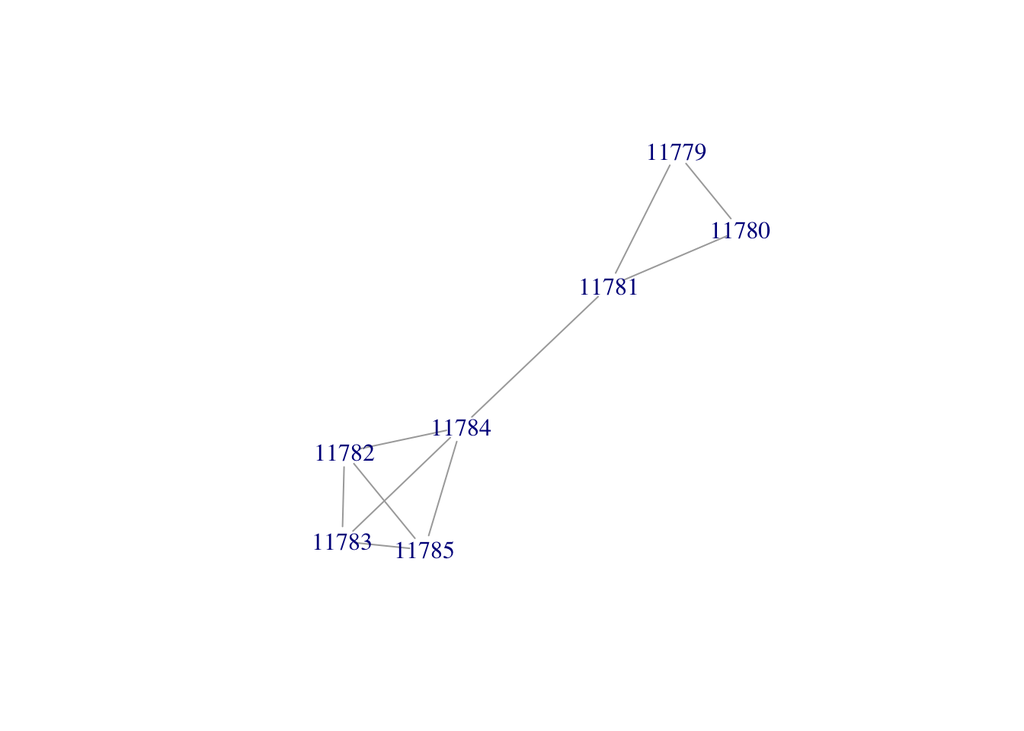

```r
##- restrict edges
el_g <- el[el[,3] < as.numeric(threshold),]
#- make igraph
g1 <- graph.data.frame( as.data.frame(el_g), directed = F )
plot(g1, vertex.shape = 'none')
```

**How neighbourhood size is calculated ?**

For now the first following calculation is performed: for each element of the donor vector, sum distances less than threshold.

```r
##- For now
t1  <- tapply(el[,3], el[,1], function(x) sum(x < 0.015)) # out
t1
```

```
## 11779 11780 11781 11782 11783 11784
##     2     1     1     3     2     1
```

What probably should be done is summing neighborhood from vertex as donor and recipient

```r
##- must add neigborhood for donor AND recipient
t2  <- tapply(el[,3], el[,2], function(x) sum(x < 0.015)) # in
t <- tapply(c(t1, t2), names(c(t1, t2)), function(x) sum(x) ) # = cluster size if complete linkage method ?
t
```

```
## 11779 11780 11781 11782 11783 11784 11785
##     2     2     3     3     3     4     3
```

Now for all individuals. In my pipeline, neighborhood size is calculated only for first column of distance matrix. And 0 size are added for tree tips not in the matrix

```r
##- how neighbourhood size is calculated ?
##- redo what is done in sim_cluster
all_nbh  <- tapply(dd[,3], dd[,1], function(x) sum(x < 0.015))
# head(all_nbh)
##- neighborhood = 0 if not in distance matrix
nbh_size <- c(all_nbh, rep(0, 12164 - length(all_nbh) ))
# summary(all_nbh)
summary(nbh_size)
```

```
##    Min. 1st Qu.  Median    Mean 3rd Qu.    Max.
##   0.000   0.000   1.000   2.544   3.000  31.000
```

```r
##- which is the same as
summary(l$nbhsize)
```

```
##    Min. 1st Qu.  Median    Mean 3rd Qu.    Max.
##   0.000   0.000   1.000   2.544   3.000  31.000
```

What I should do:

```r
##- now if adding
all_donor  <- tapply(dd[,3], dd[,1], function(x) sum(x < 0.015))
all_recip  <- tapply(dd[,3], dd[,2], function(x) sum(x < 0.015))
# head(all_donor[order(names(all_donor))])
# head(all_recip[order(names(all_recip))])
all_nbh2 <- tapply(c(all_donor, all_recip), names(c(all_donor, all_recip)), sum)
summary(all_nbh2)
```

```
##    Min. 1st Qu.  Median    Mean 3rd Qu.    Max.
##   0.000   2.000   4.000   5.634   8.000  50.000
```

```r
##- add 0 for other tips
nbh_size2 <- c(all_nbh2, rep(0, 12164 - length(all_nbh2) ))
summary(nbh_size2)
```

```
##    Min. 1st Qu.  Median    Mean 3rd Qu.    Max.
##   0.000   1.000   3.000   5.089   7.000  50.000
```

**In Erik’s code**

```r
##- check Erik's calculation
load('Erik_code/age-anal0.0.RData')
tab <- fns2agemat_tables[[1]][['tab']]
summary(tab$nbrhoodSize)
```

```
##    Min. 1st Qu.  Median    Mean 3rd Qu.    Max.
##   0.000   0.000   1.000   2.075   3.000  22.000
```

Looks like my current values of nbhsize